# Homework 2 - Visualizando dados com ggplot2

Wesley Galvão

12/06/2020

```r
# Carregamento das bibliotecas e dataset
library(ggplot2)    # library to create plots
library(ggcorrplot) # Plot correlation matrix
library(gridExtra)  # arrange plots
library(dplyr)      # tool for working with data frame like objects

data(USArrests)     # Load USArrests dataset
mydata = USArrests
```

Primeiramente, vale a pena conhecer as características e o significado da base de dados que está sendo analisada. Ao utilizar `help(USArrests)` obteve-se as seguintes informações:

> **Description**

> This data set contains statistics, in arrests per 100,000 residents for assault, murder, and rape in each of the 50 US states in 1973. Also given is the percent of the population living in urban areas.

> **Format**

> A data frame with 50 observations on 4 variables.
> - [,1] Murder numeric Murder arrests (per 100,000)
> - [,2] Assault numeric Assault arrests (per 100,000)
> - [,3] UrbanPop numeric Percent urban population
> - [,4] Rape numeric Rape arrests (per 100,000)

```r
# Exibe os nomes das colunas/variáveis
head(mydata)
```

```
##            Murder Assault UrbanPop Rape
## Alabama      13.2     236       58 21.2
## Alaska       10.0     263       48 44.5
## Arizona       8.1     294       80 31.0
## Arkansas      8.8     190       50 19.5
## California    9.0     276       91 40.6
## Colorado      7.9     204       78 38.7
```

Sabe-se que as variáveis são do tipo numérica. `Murder` e `Rape` são variáveis contínuas e `Assault` e `UrbanPop` são discretas.

## Questão 1

Utilizando o conjunto de dados `USArrests` descrito na aula, construa um histograma para cada uma das variáveis contida nesse banco de dados. Use uma cor diferente para cada histograma. Construa também box-plots para cada uma das variáveis, com as mesmas cores usadas no histograma.

- **Gráficos histograma para cada variável.**

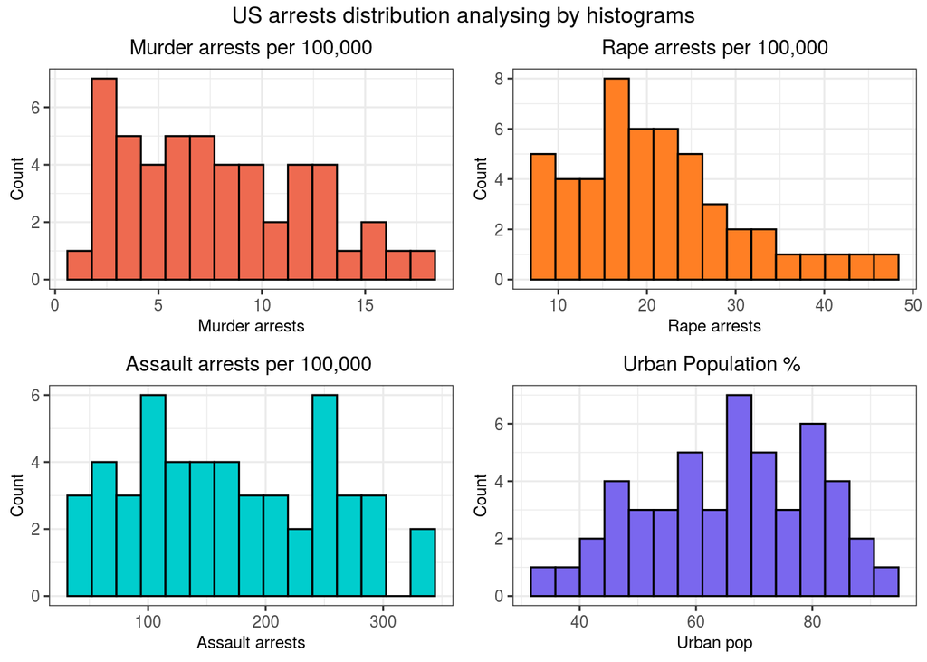

```r
hg1 = mydata %>%
    ggplot() +
    geom_histogram(aes(x = Murder), bins = 15, colour = "black", fill = "coral2") +
    labs(title = "Murder arrests per 100,000", x = "Murder arrests", y = "Count") +
    theme_bw() +
    theme(plot.title = element_text(hjust=0.5,size = 11), axis.title = element_text(size = 9))

hg2 = mydata %>%
    ggplot() +
    geom_histogram(aes(x = Rape), bins = 15, colour = "black", fill = "chocolate1") +
    labs(title = "Rape arrests per 100,000", x = "Rape arrests", y = "Count") +
    theme_bw() +
    theme(plot.title = element_text(hjust=0.5,size = 11), axis.title = element_text(size = 9))

hg3 = mydata %>%
    ggplot() +
    geom_histogram(aes(x = Assault), bins = 15, colour = "black", fill = "cyan3") +
    labs(title = "Assault arrests per 100,000 ", x = "Assault arrests", y = "Count") +
    theme_bw() +
    theme(plot.title = element_text(hjust=0.5,size = 11), axis.title = element_text(size = 9))

hg4 = mydata %>%
    ggplot() +
    geom_histogram(aes(x = UrbanPop), bins = 15, colour = "black", fill = "slateblue2") +
    labs(title = "Urban Population % ", x = "Urban pop", y = "Count") +
    theme_bw() +
    theme(plot.title = element_text(hjust=0.5,size = 11), axis.title = element_text(size = 9))


grid.arrange(hg1, hg2, hg3, hg4, ncol = 2, top = "US arrests distribution analysing by histograms")
```

- **Gráficos boxplots para cada variável.**

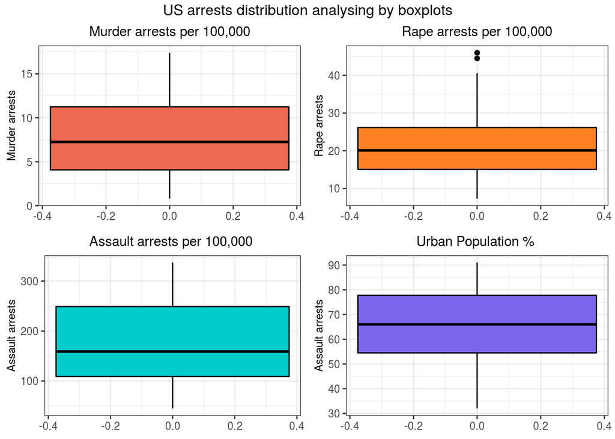

```r
bp1 = mydata %>%
    ggplot() +
    geom_boxplot(aes(y = Murder), colour = "black", fill = "coral2") +
    labs(title = "Murder arrests per 100,000", y = "Murder arrests") +
    theme_bw() +
    theme(plot.title = element_text(hjust=0.5,size = 11), axis.title = element_text(size = 9))

bp2 = mydata %>%
    ggplot() +
    geom_boxplot(aes(y = Rape), colour = "black", fill = "chocolate1") +
    labs(title = "Rape arrests per 100,000", y = "Rape arrests") +
    theme_bw() +
    theme(plot.title = element_text(hjust=0.5,size = 11), axis.title = element_text(size = 9))

bp3 = mydata %>%
    ggplot() +
    geom_boxplot(aes(y = Assault), colour = "black", fill = "cyan3") +
    labs(title = "Assault arrests per 100,000 ", y = "Assault arrests") +
    theme_bw() +
    theme(plot.title = element_text(hjust=0.5,size = 11), axis.title = element_text(size = 9))

bp4 = mydata %>%
    ggplot() +
    geom_boxplot(aes(y = UrbanPop ), colour = "black", fill = "slateblue2") +
    labs(title = "Urban Population % ", y = "Assault arrests") +
    theme_bw() +
    theme(plot.title = element_text(hjust=0.5,size = 11), axis.title = element_text(size = 9))


grid.arrange(bp1, bp2, bp3, bp4, ncol = 2, top = "US arrests distribution analysing by boxplots")
```

## Questão 2

Escolha duas variáveis do banco de dados para fazer um diagrama de dispersão (scatterplot), usando geom_point. Acrescente uma linha relacionando as duas variáveis para ajudar na interpretação. Descreva o fenômeno que você quer analisar com esse diagrama.

- Deseja-se analisar o nível de correlação entre o número de prisões por assassinato e por assalto. A pergunta para a análise é *“O número de prisões por assassinato explica o número de prísões por assalto?”*.
- Primeiramente, verifica-se o nível de correlação entre as duas variáveis: 0.8018733. Isso indica que há um alto grau de dependência entre elas, e que uma pode explicar o valor da outra.
- Agora, veja o gráfico de dispersão, onde `Murder` é a variável explicativa e `Assault` a resposta.

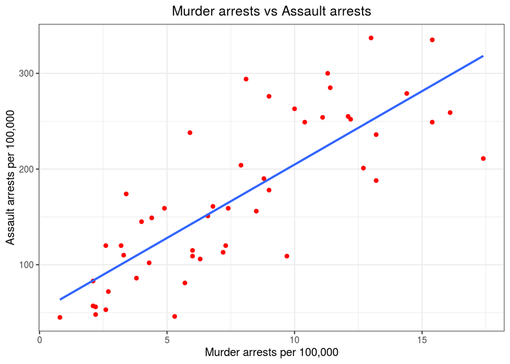

```r
sp1 <- mydata %>%
          ggplot(aes(x = Murder, y = Assault)) +
          geom_point(color = 'red') +
          geom_smooth(se = FALSE, method = "lm") +
          labs(title = "Murder arrests vs Assault arrests",
               x = "Murder arrests per 100,000", y = "Assault arrests per 100,000") +
          theme_bw() +
          theme(plot.title = element_text(hjust=0.5))

# plot scatterplot
sp1
```

- Verifica-se que há uma forte tendência linear entre ambas.

## Questão 3

Utilizando a funcão `data()` do R, escolha um conjunto de dados de sua preferência e crie 4 gráficos, a sua escolha, usando as variáveis deste banco de dados. Faça uma breve interpretação de seus achados.

- A base de dados escolhida é `iris`. Suas principais especificações são:

> **Description**

> This famous (Fisher’s or Anderson’s) iris data set gives the measurements in centimeters of the variables sepal length and width and petal length and width, respectively, for 50 flowers from each of 3 species of iris. The species are Iris setosa, versicolor, and virginica.

> **Format**

> iris is a data frame with 150 cases (rows) and 5 variables (columns) named Sepal.Length, Sepal.Width, Petal.Length, Petal.Width, and Species.

```r
# Carrega a base de dados
data("iris")
mydata2 = iris
# Exibe as primeiras linhas
head(mydata2)
```

```
##   Sepal.Length Sepal.Width Petal.Length Petal.Width Species
## 1          5.1         3.5          1.4         0.2  setosa
## 2          4.9         3.0          1.4         0.2  setosa
## 3          4.7         3.2          1.3         0.2  setosa
## 4          4.6         3.1          1.5         0.2  setosa
## 5          5.0         3.6          1.4         0.2  setosa
## 6          5.4         3.9          1.7         0.4  setosa
```

- **Frequência do comprimento das pétalas por espécie**

  Algumas estatísticas importantes.

```r
mydata2 %>%
  group_by(Species) %>%
  summarise("PL_min" = min(Petal.Length), "PL_max" = max(Petal.Length), "PL_mean"= mean(Petal.Length), "PL_median" = median(Petal.Length) )
```

```
## # A tibble: 3 x 5
##   Species    PL_min PL_max PL_mean PL_median
##   <fct>       <dbl>  <dbl>   <dbl>     <dbl>
## 1 setosa        1      1.9    1.46      1.5
## 2 versicolor    3      5.1    4.26      4.35
## 3 virginica     4.5    6.9    5.55      5.55
```

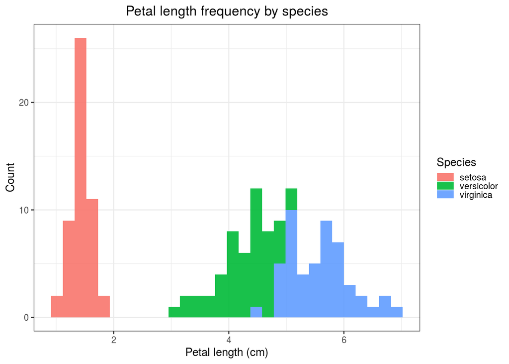

```r
ggplot(mydata2) +
  geom_histogram(aes(x = Petal.Length, fill = Species), alpha = 0.9) +
  labs(title = "Petal length frequency by species", x = "Petal length (cm)", y = "Count") +
  theme_bw() +
  theme(plot.title = element_text(hjust=0.5), legend.key.height  = unit(.1, "cm"))
```

- **Frequência do comprimento das sépalas por espécie**

  Algumas estatísticas importantes sobre comprimento das sépalas.

```r
mydata2 %>%
  group_by(Species) %>%
  summarise("SL_min" = min(Sepal.Length), "SL_max" = max(Sepal.Length), "SL_mean"= mean(Sepal.Length), "SL_median" = median(Sepal.Length))
```

```
## # A tibble: 3 x 5
##   Species    SL_min SL_max SL_mean SL_median
##   <fct>       <dbl>  <dbl>   <dbl>     <dbl>
## 1 setosa        4.3    5.8    5.01       5
## 2 versicolor    4.9    7      5.94       5.9
## 3 virginica     4.9    7.9    6.59       6.5
```

- Diferentemente do gráfico anterior, a distribuição é dada individualmente por espécie. Os pontos destacar-se são:
  - As espécies aparentam ter uma distribuição próxima de uma normal.
  - Há intersecção de valores entre as espécies nos seus extremos.
  - A espécie virgínica aparenta ter dois outliers.

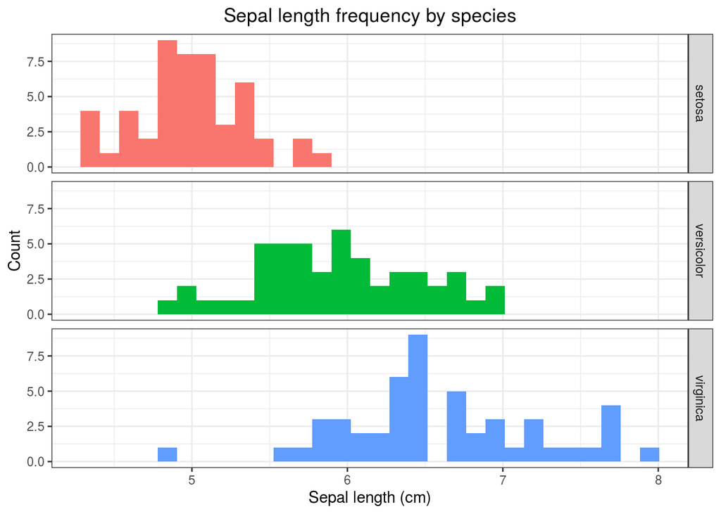

```r
ggplot(mydata2) +
  geom_histogram(aes(x = Sepal.Length, fill = Species)) +
  facet_grid(Species~.) +
  labs(title = "Sepal length frequency by species", x = "Sepal length (cm)", y = "Count") +
  theme_bw() +
  theme(plot.title = element_text(hjust=0.5), legend.key.height  = unit(.1, "cm"), legend.position="none")
```

- **Boxplot da largura das sépalas por espécie**
  - Ambas as espécies setosa e virgínica possuem outliers nos valores para a largura das sépalas.
  - Como mecionado anteriormente, há intersecção dos valores nos extremos, o que pode causar confusão na classificação das espécies.
  - Embora haja um pequeno deslocamento do segundo quartil em ambas as caixas das espécies, isso revela uma distribuição assimétrica.
  - As espécies setosa e versicolor apresentam maiores variabilidades em seus valores, comparados aos valores da virgínica.

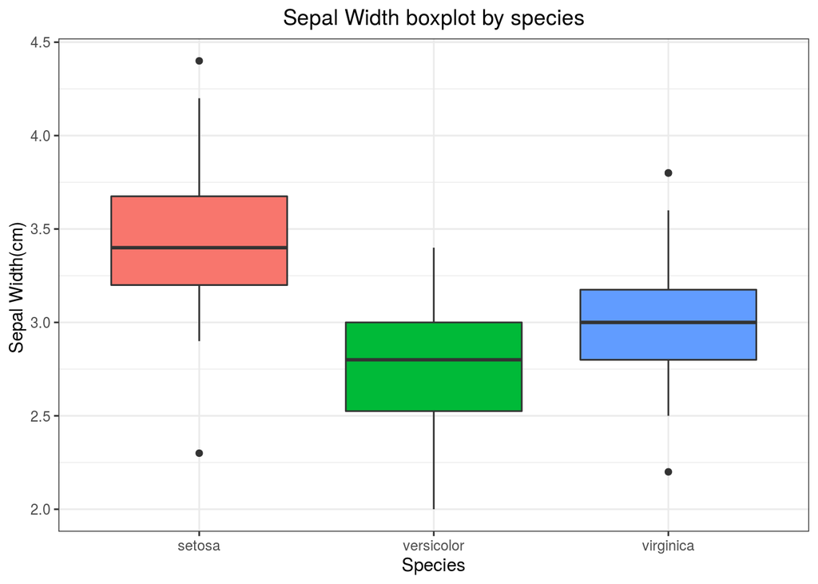

```r
mydata2 %>%
    ggplot() +
    geom_boxplot(aes(x = Species, y = Sepal.Width, fill = Species), show.legend = FALSE) +
    labs(title = "Sepal Width boxplot by species", y = "Sepal Width(cm) ", x = "Species") +
    theme_bw() +
    theme(plot.title = element_text(hjust=0.5))
```

- **Gráfico da matrix de correlação**

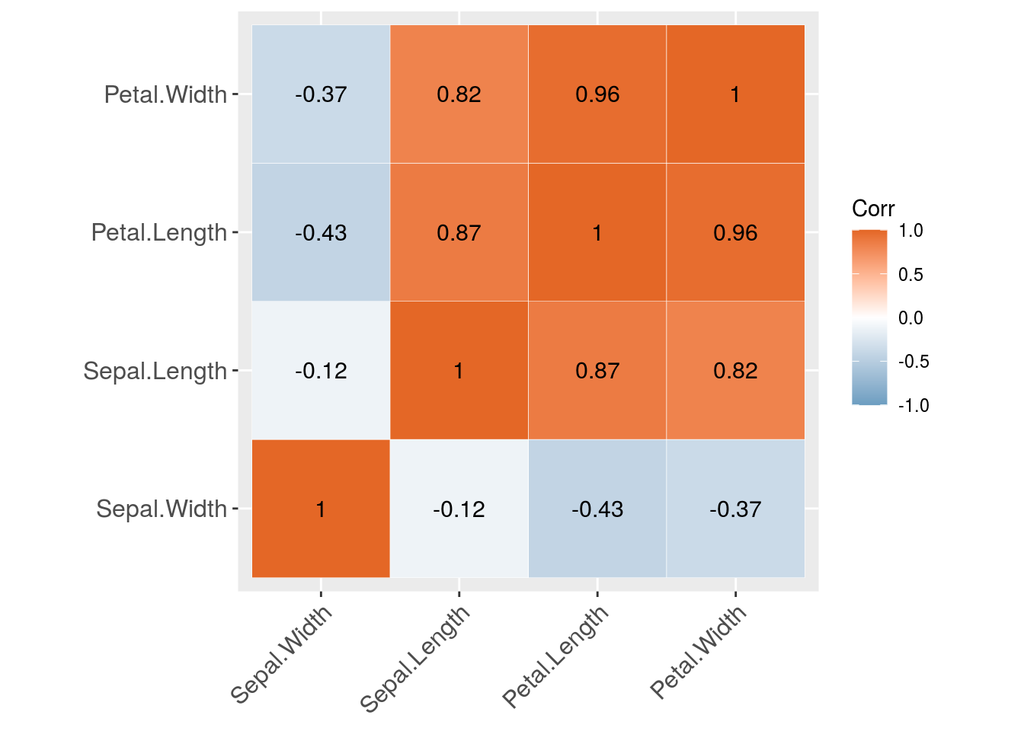

```r
#Seleciona as variáveis e cria a matrix de correlação
var_cor <- iris %>%
  dplyr::select(Sepal.Length, Sepal.Width, Petal.Length,
        Petal.Width)
var_cor <- cor(var_cor)

#Plota a matrix de correlação
ggcorrplot(
  var_cor,
  lab = TRUE,
  hc.order = TRUE,
  outline.color = "white",
  ggtheme = ggplot2::theme_gray,
  colors = c("#6D9EC1", "white", "#E46726"),

)
```

## Questão 4

Considerando o banco de dados utilizado no exercício anterior, escolha duas variáveis para analisar via diagrama de dispersão. Comente brevemente seus achados.

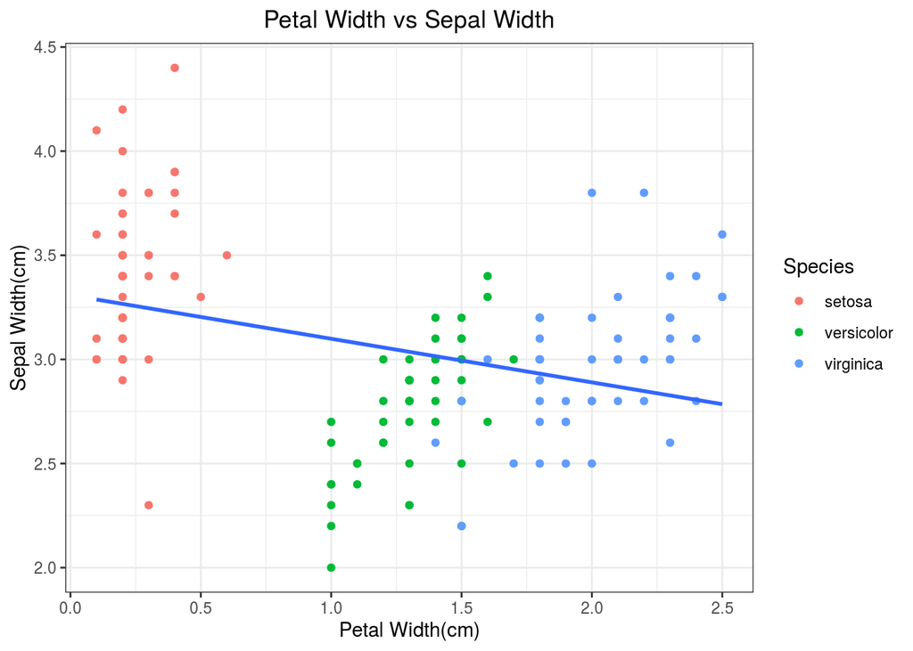

```r
mydata2 %>%
      ggplot(aes(x = Petal.Width, y = Sepal.Width)) +
      geom_point(aes(colour = Species) ) +
      geom_smooth(se = FALSE, method = "lm") +
      labs(title = "Petal Width vs Sepal Width",
             x = "Petal Width(cm)", y = "Sepal Width(cm)") +
      theme_bw() +
      theme(plot.title = element_text(hjust=0.5))
```